# rhdi-cpi-comparison

## A quick exploration of CPI and RHDI

Real household disposable income, volume index (RHDI), “is an economic measure that reflects the inflation-adjusted amount of income households have available for spending, saving, or investing after accounting for taxes and transfers. It is expressed as an index, allowing for comparisons over time.”

Just like the CPI, it has an index reference period, a year where the index value starts at 100%. Every following or preceding year shows the value as a decrease or increase from that base year in percent. For example, if the value = 100 in 2002 and 110 in 2003 that is a 10% increase.

```r
library(tidyverse)
library(readxl)
library(lubridate)

rhdi <- read.csv("data/real-household-disposable-income.csv")
cpi <- read_xlsx("data/cpi-food-v-all-1974-2024.xlsx", skip = 3)

# cleaning and selecting data
rhdi <- rhdi |> filter(Estimates == "Real household disposable income, volume index 2017=100") |>
  select(REF_DATE, VALUE) |>
  mutate(date  = ym(REF_DATE),
         .keep = "unused") |>
  rename(rhdi_2017base = VALUE)
```

RHDI data: https://www150.statcan.gc.ca/t1/tbl1/en/tv.action?pid=3610010501

CPI data: https://www150.statcan.gc.ca/n1/pub/71-607-x/2018016/cpilg-ipcgl-eng.htm

In order to compare the RHDI with the CPI, the index reference periods have to match. This code adjusts the RHDI data to match the CPI’s. It also groups the CPI data into quarterly since RHDI is quarterly data and CPI is monthly. To aggregate the values, I took the last value in the quarter which makes more sense than an average.

```r
# base_2017 value for new base year adjustment
rhdi_2002 <- rhdi |>
  filter(date == date("2002-07-01")) |>
  select(rhdi_2017base) |>
  pull()

# adjust the base year
rhdi <- rhdi |>
  mutate(rhdi = round((rhdi_2017base /rhdi_2002 * 100),1),
         .keep = "unused")

# cleaning, selecting, and joining with rhdi data
cpi_base <- cpi |>
  select(date, `All-items...2`, Food...3) |>
  rename(all_items = `All-items...2`, food = Food...3) |>
  group_by(date = quarter(date,type = "date_first", fiscal_start = 1)) |>
  summarise(all_items = last(all_items), food = last(food)) |>
  left_join(rhdi, join_by(date)) |>
  pivot_longer(cols = -date, names_to = "cpi_item", values_to = "base_value")
```

Then I created a year over year % change mutation for the RHDI before plotting them.

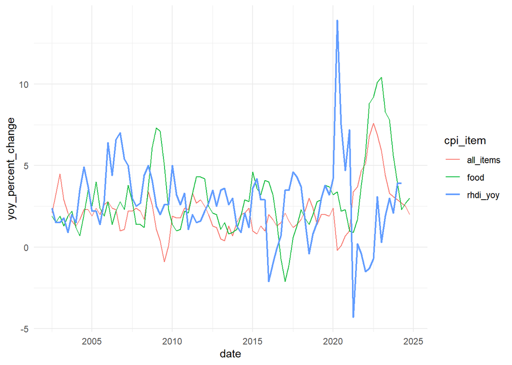

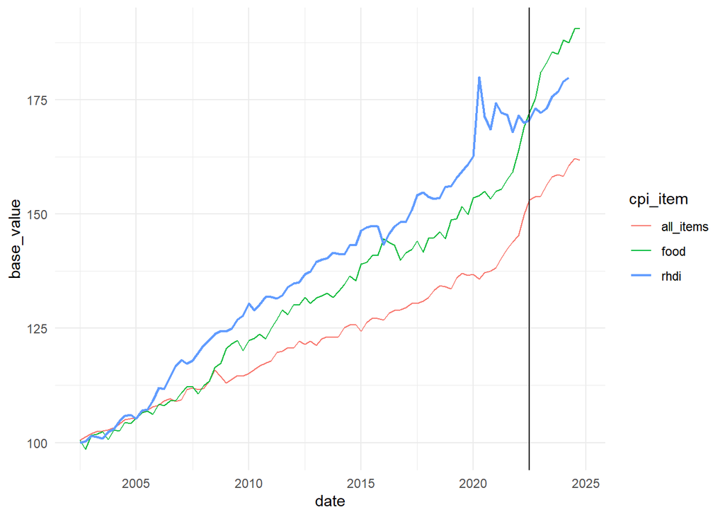

```r
# this finds the year that the food cpi overtakes the RHDI
# used for highlightin with a vertical line on the plot
year_food_overtakes_rhdi <- cpi |>
  select(date, `All-items...2`, Food...3) |>
  rename(all_items = `All-items...2`, food = Food...3) |>
  group_by(date = quarter(date,type = "date_first", fiscal_start = 1)) |>
  summarise(all_items = last(all_items), food = last(food)) |>
  left_join(rhdi, join_by(date)) |>
  filter(food >= rhdi, date > "2020-01-01") |>
  select(date) |>
  slice_min(order_by = date) |>
  pull()

# creating a dataframe with the RHDI year over year (yoy) percent change
rhdi_yoy <- rhdi |>
  mutate(rhdi_yoy = round(((rhdi - lag(rhdi, 4)) / lag(rhdi, 4) * 100),1),
         .keep = "unused")

# joining the cpi yoy with rhdi yoy data
yoy <- cpi |>
  select(date, `All-items...4`, Food...5) |>
  rename(all_items = `All-items...4`, food = Food...5) |>
  group_by(date = quarter(date, type = "date_first", fiscal_start = 1)) |>
  summarise(all_items = last(all_items), food = last(food)) |>
  left_join(rhdi_yoy, join_by(date)) |>
  pivot_longer(cols = -date, names_to = "cpi_item", values_to = "yoy_percent_change")

# plotting the yoy
yoy |>
  filter(date > "2002-06-01") |>
  ggplot(aes(x = date, y = yoy_percent_change, color = cpi_item)) +
  geom_line() +
  geom_line(data = filter(yoy,cpi_item == "rhdi_yoy", date > "2002-06-01"), size = 0.8) +
  theme_minimal()
# plotting the cpi and rhdi base values
cpi_base |>
  filter(date > "2002-06-01") |>
  ggplot(aes(x = date, y = base_value, colour = cpi_item)) +
  geom_line() +
  geom_line(data = filter(cpi_base, cpi_item == "rhdi", date > "2002-06-01"), size = 0.8) +
  geom_vline(xintercept = year_food_overtakes_rhdi) +
  theme_minimal()
```